# MidtermProject

## Kaggle - House Prices: Advanced Regression Techniques

#### Brandon Woo

```python
import pandas as pd
import numpy as np
import matplotlib.pyplot as plt
import seaborn as sns
```

```python
train = pd.read_csv("train.csv")
```

```python
train*2
```

|  | Id | MSSubClass | MSZoning | LotFrontage | LotArea | Street | Alley | LotShape | LandContour | Utilities | LotConfig | LandSlope | Neighborhood | Condition1 | Condition2 | BldgType | HouseStyle | OverallQual | OverallCond | YearBuilt | YearRemodAdd | RoofStyle | RoofMatl | Exterior1st | Exterior2nd | MasVnrType | MasVnrArea | ExterQual | ExterCond | … |
| --- | --- | --- | --- | --- | --- | --- | --- | --- | --- | --- | --- | --- | --- | --- | --- | --- | --- | --- | --- | --- | --- | --- | --- | --- | --- | --- | --- | --- | --- | --- |
| 0 | 2 | 120 | RLRL | 130.0 | 16900 | PavePave | NaN | RegReg | LvlLvl | AllPubAllPub | InsideInside | GtlGtl | CollgCrCollgCr | NormNorm | NormNorm | 1Fam1Fam | 2Story2Story | 14 | 10 | 4006 | 4006 | GableGable | CompShgCompShg | VinylSdVinylSd | VinylSdVinylSd | BrkFaceBrkFace | 392.0 | GdGd | TATA | … |
| 1 | 4 | 40 | RLRL | 160.0 | 19200 | PavePave | NaN | RegReg | LvlLvl | AllPubAllPub | FR2FR2 | GtlGtl | VeenkerVeenker | FeedrFeedr | NormNorm | 1Fam1Fam | 1Story1Story | 12 | 16 | 3952 | 3952 | GableGable | CompShgCompShg | MetalSdMetalSd | MetalSdMetalSd | NoneNone | 0.0 | TATA | TATA | … |
| 2 | 6 | 120 | RLRL | 136.0 | 22500 | PavePave | NaN | IR1IR1 | LvlLvl | AllPubAllPub | InsideInside | GtlGtl | CollgCrCollgCr | NormNorm | NormNorm | 1Fam1Fam | 2Story2Story | 14 | 10 | 4002 | 4004 | GableGable | CompShgCompShg | VinylSdVinylSd | VinylSdVinylSd | BrkFaceBrkFace | 324.0 | GdGd | TATA | … |
| 3 | 8 | 140 | RLRL | 120.0 | 19100 | PavePave | NaN | IR1IR1 | LvlLvl | AllPubAllPub | CornerCorner | GtlGtl | CrawforCrawfor | NormNorm | NormNorm | 1Fam1Fam | 2Story2Story | 14 | 10 | 3830 | 3940 | GableGable | CompShgCompShg | Wd SdngWd Sdng | Wd ShngWd Shng | NoneNone | 0.0 | TATA | TATA | … |
| 4 | 10 | 120 | RLRL | 168.0 | 28520 | PavePave | NaN | IR1IR1 | LvlLvl | AllPubAllPub | FR2FR2 | GtlGtl | NoRidgeNoRidge | NormNorm | NormNorm | 1Fam1Fam | 2Story2Story | 16 | 10 | 4000 | 4000 | GableGable | CompShgCompShg | VinylSdVinylSd | VinylSdVinylSd | BrkFaceBrkFace | 700.0 | GdGd | TATA | … |
| ... | ... | ... | ... | ... | ... | ... | ... | ... | ... | ... | ... | ... | ... | ... | ... | ... | ... | ... | ... | ... | ... | ... | ... | ... | ... | ... | ... | ... | ... | … |
| 1455 | 2912 | 120 | RLRL | 124.0 | 15834 | PavePave | NaN | RegReg | LvlLvl | AllPubAllPub | InsideInside | GtlGtl | GilbertGilbert | NormNorm | NormNorm | 1Fam1Fam | 2Story2Story | 12 | 10 | 3998 | 4000 | GableGable | CompShgCompShg | VinylSdVinylSd | VinylSdVinylSd | NoneNone | 0.0 | TATA | TATA | … |
| 1456 | 2914 | 40 | RLRL | 170.0 | 26350 | PavePave | NaN | RegReg | LvlLvl | AllPubAllPub | InsideInside | GtlGtl | NWAmesNWAmes | NormNorm | NormNorm | 1Fam1Fam | 1Story1Story | 12 | 12 | 3956 | 3976 | GableGable | CompShgCompShg | PlywoodPlywood | PlywoodPlywood | StoneStone | 238.0 | TATA | TATA | … |
| 1457 | 2916 | 140 | RLRL | 132.0 | 18084 | PavePave | NaN | RegReg | LvlLvl | AllPubAllPub | InsideInside | GtlGtl | CrawforCrawfor | NormNorm | NormNorm | 1Fam1Fam | 2Story2Story | 14 | 18 | 3882 | 4012 | GableGable | CompShgCompShg | CemntBdCemntBd | CmentBdCmentBd | NoneNone | 0.0 | ExEx | GdGd | … |
| 1458 | 2918 | 40 | RLRL | 136.0 | 19434 | PavePave | NaN | RegReg | LvlLvl | AllPubAllPub | InsideInside | GtlGtl | NAmesNAmes | NormNorm | NormNorm | 1Fam1Fam | 1Story1Story | 10 | 12 | 3900 | 3992 | HipHip | CompShgCompShg | MetalSdMetalSd | MetalSdMetalSd | NoneNone | 0.0 | TATA | TATA | … |
| 1459 | 2920 | 40 | RLRL | 150.0 | 19874 | PavePave | NaN | RegReg | LvlLvl | AllPubAllPub | InsideInside | GtlGtl | EdwardsEdwards | NormNorm | NormNorm | 1Fam1Fam | 1Story1Story | 10 | 12 | 3930 | 3930 | GableGable | CompShgCompShg | HdBoardHdBoard | HdBoardHdBoard | NoneNone | 0.0 | GdGd | TATA | … |

1460 rows × 81 columns

```python
train = train.set_index("Id")
```

```python
test = pd.read_csv("test.csv")
```

```python
test.head()
```

|  | Id | MSSubClass | MSZoning | LotFrontage | LotArea | Street | Alley | LotShape | LandContour | Utilities | ... | ScreenPorch | PoolArea | PoolQC | Fence | MiscFeature | MiscVal | MoSold | YrSold | SaleType | SaleCondition |
| --- | --- | --- | --- | --- | --- | --- | --- | --- | --- | --- | --- | --- | --- | --- | --- | --- | --- | --- | --- | --- | --- |
| 0 | 1461 | 20 | RH | 80.0 | 11622 | Pave | NaN | Reg | Lvl | AllPub | ... | 120 | 0 | NaN | MnPrv | NaN | 0 | 6 | 2010 | WD | Normal |
| 1 | 1462 | 20 | RL | 81.0 | 14267 | Pave | NaN | IR1 | Lvl | AllPub | ... | 0 | 0 | NaN | NaN | Gar2 | 12500 | 6 | 2010 | WD | Normal |
| 2 | 1463 | 60 | RL | 74.0 | 13830 | Pave | NaN | IR1 | Lvl | AllPub | ... | 0 | 0 | NaN | MnPrv | NaN | 0 | 3 | 2010 | WD | Normal |
| 3 | 1464 | 60 | RL | 78.0 | 9978 | Pave | NaN | IR1 | Lvl | AllPub | ... | 0 | 0 | NaN | NaN | NaN | 0 | 6 | 2010 | WD | Normal |
| 4 | 1465 | 120 | RL | 43.0 | 5005 | Pave | NaN | IR1 | HLS | AllPub | ... | 144 | 0 | NaN | NaN | NaN | 0 | 1 | 2010 | WD | Normal |

5 rows × 80 columns

```python
pd.set_option('display.max_columns', 81)
```

```python
train.isnull().sum()/len(train)*100
```

```
MSSubClass        0.000000
MSZoning          0.000000
LotFrontage      17.739726
LotArea           0.000000
Street            0.000000
                   ...
MoSold            0.000000
YrSold            0.000000
SaleType          0.000000
SaleCondition     0.000000
SalePrice         0.000000
Length: 80, dtype: float64
```

```python
train.describe()
```

|  | MSSubClass | LotFrontage | LotArea | OverallQual | OverallCond | YearBuilt | YearRemodAdd | MasVnrArea | BsmtFinSF1 | BsmtFinSF2 | BsmtUnfSF | TotalBsmtSF | 1stFlrSF | 2ndFlrSF | LowQualFinSF | GrLivArea | BsmtFullBath | BsmtHalfBath | FullBath | HalfBath | BedroomAbvGr | KitchenAbvGr | TotRmsAbvGrd | Fireplaces | GarageYrBlt | GarageCars | GarageArea | WoodDeckSF | OpenPorchSF | … |
| --- | --- | --- | --- | --- | --- | --- | --- | --- | --- | --- | --- | --- | --- | --- | --- | --- | --- | --- | --- | --- | --- | --- | --- | --- | --- | --- | --- | --- | --- | --- |
| count | 1460.000000 | 1201.000000 | 1460.000000 | 1460.000000 | 1460.000000 | 1460.000000 | 1460.000000 | 1452.000000 | 1460.000000 | 1460.000000 | 1460.000000 | 1460.000000 | 1460.000000 | 1460.000000 | 1460.000000 | 1460.000000 | 1460.000000 | 1460.000000 | 1460.000000 | 1460.000000 | 1460.000000 | 1460.000000 | 1460.000000 | 1460.000000 | 1379.000000 | 1460.000000 | 1460.000000 | 1460.000000 | 1460.000000 | … |
| mean | 56.897260 | 70.049958 | 10516.828082 | 6.099315 | 5.575342 | 1971.267808 | 1984.865753 | 103.685262 | 443.639726 | 46.549315 | 567.240411 | 1057.429452 | 1162.626712 | 346.992466 | 5.844521 | 1515.463699 | 0.425342 | 0.057534 | 1.565068 | 0.382877 | 2.866438 | 1.046575 | 6.517808 | 0.613014 | 1978.506164 | 1.767123 | 472.980137 | 94.244521 | 46.660274 | … |
| std | 42.300571 | 24.284752 | 9981.264932 | 1.382997 | 1.112799 | 30.202904 | 20.645407 | 181.066207 | 456.098091 | 161.319273 | 441.866955 | 438.705324 | 386.587738 | 436.528436 | 48.623081 | 525.480383 | 0.518911 | 0.238753 | 0.550916 | 0.502885 | 0.815778 | 0.220338 | 1.625393 | 0.644666 | 24.689725 | 0.747315 | 213.804841 | 125.338794 | 66.256028 | … |
| min | 20.000000 | 21.000000 | 1300.000000 | 1.000000 | 1.000000 | 1872.000000 | 1950.000000 | 0.000000 | 0.000000 | 0.000000 | 0.000000 | 0.000000 | 334.000000 | 0.000000 | 0.000000 | 334.000000 | 0.000000 | 0.000000 | 0.000000 | 0.000000 | 0.000000 | 0.000000 | 2.000000 | 0.000000 | 1900.000000 | 0.000000 | 0.000000 | 0.000000 | 0.000000 | … |
| 25% | 20.000000 | 59.000000 | 7553.500000 | 5.000000 | 5.000000 | 1954.000000 | 1967.000000 | 0.000000 | 0.000000 | 0.000000 | 223.000000 | 795.750000 | 882.000000 | 0.000000 | 0.000000 | 1129.500000 | 0.000000 | 0.000000 | 1.000000 | 0.000000 | 2.000000 | 1.000000 | 5.000000 | 0.000000 | 1961.000000 | 1.000000 | 334.500000 | 0.000000 | 0.000000 | … |
| 50% | 50.000000 | 69.000000 | 9478.500000 | 6.000000 | 5.000000 | 1973.000000 | 1994.000000 | 0.000000 | 383.500000 | 0.000000 | 477.500000 | 991.500000 | 1087.000000 | 0.000000 | 0.000000 | 1464.000000 | 0.000000 | 0.000000 | 2.000000 | 0.000000 | 3.000000 | 1.000000 | 6.000000 | 1.000000 | 1980.000000 | 2.000000 | 480.000000 | 0.000000 | 25.000000 | … |
| 75% | 70.000000 | 80.000000 | 11601.500000 | 7.000000 | 6.000000 | 2000.000000 | 2004.000000 | 166.000000 | 712.250000 | 0.000000 | 808.000000 | 1298.250000 | 1391.250000 | 728.000000 | 0.000000 | 1776.750000 | 1.000000 | 0.000000 | 2.000000 | 1.000000 | 3.000000 | 1.000000 | 7.000000 | 1.000000 | 2002.000000 | 2.000000 | 576.000000 | 168.000000 | 68.000000 | … |
| max | 190.000000 | 313.000000 | 215245.000000 | 10.000000 | 9.000000 | 2010.000000 | 2010.000000 | 1600.000000 | 5644.000000 | 1474.000000 | 2336.000000 | 6110.000000 | 4692.000000 | 2065.000000 | 572.000000 | 5642.000000 | 3.000000 | 2.000000 | 3.000000 | 2.000000 | 8.000000 | 3.000000 | 14.000000 | 3.000000 | 2010.000000 | 4.000000 | 1418.000000 | 857.000000 | 547.000000 | … |

```python
from collections import Counter
Counter(train.isna().any())
```

```
Counter({False: 61, True: 19})
```

```python
train.fillna(train.mean(),inplace=True)
train
```

| Id | MSSubClass | MSZoning | LotFrontage | LotArea | Street | Alley | LotShape | LandContour | Utilities | LotConfig | LandSlope | Neighborhood | Condition1 | Condition2 | BldgType | HouseStyle | OverallQual | OverallCond | YearBuilt | YearRemodAdd | RoofStyle | RoofMatl | Exterior1st | Exterior2nd | MasVnrType | MasVnrArea | ExterQual | ExterCond | Foundation | … |
| --- | --- | --- | --- | --- | --- | --- | --- | --- | --- | --- | --- | --- | --- | --- | --- | --- | --- | --- | --- | --- | --- | --- | --- | --- | --- | --- | --- | --- | --- | --- |
| 1 | 60 | RL | 65.0 | 8450 | Pave | NaN | Reg | Lvl | AllPub | Inside | Gtl | CollgCr | Norm | Norm | 1Fam | 2Story | 7 | 5 | 2003 | 2003 | Gable | CompShg | VinylSd | VinylSd | BrkFace | 196.0 | Gd | TA | PConc | … |
| 2 | 20 | RL | 80.0 | 9600 | Pave | NaN | Reg | Lvl | AllPub | FR2 | Gtl | Veenker | Feedr | Norm | 1Fam | 1Story | 6 | 8 | 1976 | 1976 | Gable | CompShg | MetalSd | MetalSd | None | 0.0 | TA | TA | CBlock | … |
| 3 | 60 | RL | 68.0 | 11250 | Pave | NaN | IR1 | Lvl | AllPub | Inside | Gtl | CollgCr | Norm | Norm | 1Fam | 2Story | 7 | 5 | 2001 | 2002 | Gable | CompShg | VinylSd | VinylSd | BrkFace | 162.0 | Gd | TA | PConc | … |
| 4 | 70 | RL | 60.0 | 9550 | Pave | NaN | IR1 | Lvl | AllPub | Corner | Gtl | Crawfor | Norm | Norm | 1Fam | 2Story | 7 | 5 | 1915 | 1970 | Gable | CompShg | Wd Sdng | Wd Shng | None | 0.0 | TA | TA | BrkTil | … |
| 5 | 60 | RL | 84.0 | 14260 | Pave | NaN | IR1 | Lvl | AllPub | FR2 | Gtl | NoRidge | Norm | Norm | 1Fam | 2Story | 8 | 5 | 2000 | 2000 | Gable | CompShg | VinylSd | VinylSd | BrkFace | 350.0 | Gd | TA | PConc | … |
| ... | ... | ... | ... | ... | ... | ... | ... | ... | ... | ... | ... | ... | ... | ... | ... | ... | ... | ... | ... | ... | ... | ... | ... | ... | ... | ... | ... | ... | ... | … |
| 1456 | 60 | RL | 62.0 | 7917 | Pave | NaN | Reg | Lvl | AllPub | Inside | Gtl | Gilbert | Norm | Norm | 1Fam | 2Story | 6 | 5 | 1999 | 2000 | Gable | CompShg | VinylSd | VinylSd | None | 0.0 | TA | TA | PConc | … |
| 1457 | 20 | RL | 85.0 | 13175 | Pave | NaN | Reg | Lvl | AllPub | Inside | Gtl | NWAmes | Norm | Norm | 1Fam | 1Story | 6 | 6 | 1978 | 1988 | Gable | CompShg | Plywood | Plywood | Stone | 119.0 | TA | TA | CBlock | … |
| 1458 | 70 | RL | 66.0 | 9042 | Pave | NaN | Reg | Lvl | AllPub | Inside | Gtl | Crawfor | Norm | Norm | 1Fam | 2Story | 7 | 9 | 1941 | 2006 | Gable | CompShg | CemntBd | CmentBd | None | 0.0 | Ex | Gd | Stone | … |
| 1459 | 20 | RL | 68.0 | 9717 | Pave | NaN | Reg | Lvl | AllPub | Inside | Gtl | NAmes | Norm | Norm | 1Fam | 1Story | 5 | 6 | 1950 | 1996 | Hip | CompShg | MetalSd | MetalSd | None | 0.0 | TA | TA | CBlock | … |
| 1460 | 20 | RL | 75.0 | 9937 | Pave | NaN | Reg | Lvl | AllPub | Inside | Gtl | Edwards | Norm | Norm | 1Fam | 1Story | 5 | 6 | 1965 | 1965 | Gable | CompShg | HdBoard | HdBoard | None | 0.0 | Gd | TA | CBlock | … |

1460 rows × 80 columns

```python
Counter(train.isna().any())
```

```
Counter({False: 64, True: 16})
```

### Data Cleaning

So far I just read given data training and testing data sets on houses. The first thing that came to mind was to start check the data quality and cleaning the data. This meant I wanted to look for any columns with NaN and bad values that did not make sense. At first there were about 19 columns that had missing or bad values. I then replaced the numerical columns that had NaN with the mean values of the column. This decreased the count of bad columns to 16. I realized that the other columns that needed to be fixed were categorical. I believe these values are harder to fix, I could have used the mode to replace the NaN or not used that column at all. But then I realized after reading the data_description.txt, any categorical columns that contained the values NaN really meant that there was none of that specific object. So I decided to just change the value to none, because the data was correct.

```python
train.fillna("None",inplace=True)
```

```python
Counter(train.isna().any())
```

```
Counter({False: 80})
```

```python
numerical_columns = train.var()
```

```python
numerical_columns
```

```
MSSubClass       1.789338e+03
LotFrontage      4.850576e+02
LotArea          9.962565e+07
OverallQual      1.912679e+00
OverallCond      1.238322e+00
YearBuilt        9.122154e+02
YearRemodAdd     4.262328e+02
MasVnrArea       3.260520e+04
BsmtFinSF1       2.080255e+05
BsmtFinSF2       2.602391e+04
BsmtUnfSF        1.952464e+05
TotalBsmtSF      1.924624e+05
1stFlrSF         1.494501e+05
2ndFlrSF         1.905571e+05
LowQualFinSF     2.364204e+03
GrLivArea        2.761296e+05
BsmtFullBath     2.692682e-01
BsmtHalfBath     5.700283e-02
FullBath         3.035082e-01
HalfBath         2.528937e-01
BedroomAbvGr     6.654938e-01
KitchenAbvGr     4.854892e-02
TotRmsAbvGrd     2.641903e+00
Fireplaces       4.155947e-01
GarageYrBlt      5.757400e+02
GarageCars       5.584797e-01
GarageArea       4.571251e+04
WoodDeckSF       1.570981e+04
OpenPorchSF      4.389861e+03
EnclosedPorch    3.735550e+03
3SsnPorch        8.595059e+02
ScreenPorch      3.108889e+03
PoolArea         1.614216e+03
MiscVal          2.461381e+05
MoSold           7.309595e+00
YrSold           1.763837e+00
SalePrice        6.311111e+09
dtype: float64
```

### Feature Selection

So here I calculated the variance for all of the numerical features. What I am trying to do is to reduce the number of features in a dataset without havng to lose too much information. I am trying to improve the model by using dimensionality reduction techniques. Hopefully the model will run faster and remove redundant features since there are less dimensions. This is a variance check, we don't want the feautres in out dataset to have the same values or bring the same insights. Zero variance will lead to no difference in prediction.

```python
dict(reversed(sorted(zip(numerical_columns.values, numerical_columns.keys()))))
```

```
{6311111264.297451: 'SalePrice',
 99625649.6503417: 'LotArea',
 276129.63336259616: 'GrLivArea',
 246138.0553972849: 'MiscVal',
 208025.46846873628: 'BsmtFinSF1',
 195246.40617940607: 'BsmtUnfSF',
 192462.36170908928: 'TotalBsmtSF',
 190557.0753373038: '2ndFlrSF',
 149450.07920371392: '1stFlrSF',
 45712.51022890529: 'GarageArea',
 32605.204362303895: 'MasVnrArea',
 26023.90777883106: 'BsmtFinSF2',
 15709.813369543657: 'WoodDeckSF',
 4389.861203488976: 'OpenPorchSF',
 3735.5503258002063: 'EnclosedPorch',
 3108.889358915411: 'ScreenPorch',
 2364.204048090632: 'LowQualFinSF',
 1789.338306402389: 'MSSubClass',
 1614.215993315013: 'PoolArea',
 912.2154126019891: 'YearBuilt',
 859.5058709756354: '3SsnPorch',
 575.7400257758463: 'GarageYrBlt',
 485.0575753926782: 'LotFrontage',
 426.2328222558135: 'YearRemodAdd',
 7.309594674528473: 'MoSold',
 2.6419033490756916: 'TotRmsAbvGrd',
 1.9126794482991696: 'OverallQual',
 1.763836649234308: 'YrSold',
 1.2383223637883065: 'OverallCond',
 0.6654938173077709: 'BedroomAbvGr',
 0.5584797243373708: 'GarageCars',
 0.41559474964087506: 'Fireplaces',
 0.30350822011698775: 'FullBath',
 0.2692682171124828: 'BsmtFullBath',
 0.25289370651694854: 'HalfBath',
 0.05700282610532444: 'BsmtHalfBath',
 0.048548921667120055: 'KitchenAbvGr'}
```

I printed out the variance scores for all the numerical features, and ordered them by their variance from greatest to least. I came to the realization that the variance becomes less impactful once it hits around the OpenPorchSF and another cut off at MoSold. I decided I didn't want to cut out too many features, so I cut off OpenPorchSF and down.

```python
for each in numerical_columns.keys():
    if numerical_columns[each] <= 5000:
        train.drop(each,1,inplace=True)
train
```

| Id | MSZoning | LotArea | Street | Alley | LotShape | LandContour | Utilities | LotConfig | LandSlope | Neighborhood | Condition1 | Condition2 | BldgType | HouseStyle | RoofStyle | RoofMatl | Exterior1st | Exterior2nd | MasVnrType | MasVnrArea | ExterQual | ExterCond | Foundation | BsmtQual | BsmtCond | BsmtExposure | BsmtFinType1 | BsmtFinSF1 | BsmtFinType2 | … |
| --- | --- | --- | --- | --- | --- | --- | --- | --- | --- | --- | --- | --- | --- | --- | --- | --- | --- | --- | --- | --- | --- | --- | --- | --- | --- | --- | --- | --- | --- | --- |
| 1 | RL | 8450 | Pave | None | Reg | Lvl | AllPub | Inside | Gtl | CollgCr | Norm | Norm | 1Fam | 2Story | Gable | CompShg | VinylSd | VinylSd | BrkFace | 196.0 | Gd | TA | PConc | Gd | TA | No | GLQ | 706 | Unf | … |
| 2 | RL | 9600 | Pave | None | Reg | Lvl | AllPub | FR2 | Gtl | Veenker | Feedr | Norm | 1Fam | 1Story | Gable | CompShg | MetalSd | MetalSd | None | 0.0 | TA | TA | CBlock | Gd | TA | Gd | ALQ | 978 | Unf | … |
| 3 | RL | 11250 | Pave | None | IR1 | Lvl | AllPub | Inside | Gtl | CollgCr | Norm | Norm | 1Fam | 2Story | Gable | CompShg | VinylSd | VinylSd | BrkFace | 162.0 | Gd | TA | PConc | Gd | TA | Mn | GLQ | 486 | Unf | … |
| 4 | RL | 9550 | Pave | None | IR1 | Lvl | AllPub | Corner | Gtl | Crawfor | Norm | Norm | 1Fam | 2Story | Gable | CompShg | Wd Sdng | Wd Shng | None | 0.0 | TA | TA | BrkTil | TA | Gd | No | ALQ | 216 | Unf | … |
| 5 | RL | 14260 | Pave | None | IR1 | Lvl | AllPub | FR2 | Gtl | NoRidge | Norm | Norm | 1Fam | 2Story | Gable | CompShg | VinylSd | VinylSd | BrkFace | 350.0 | Gd | TA | PConc | Gd | TA | Av | GLQ | 655 | Unf | … |
| ... | ... | ... | ... | ... | ... | ... | ... | ... | ... | ... | ... | ... | ... | ... | ... | ... | ... | ... | ... | ... | ... | ... | ... | ... | ... | ... | ... | ... | ... | … |
| 1456 | RL | 7917 | Pave | None | Reg | Lvl | AllPub | Inside | Gtl | Gilbert | Norm | Norm | 1Fam | 2Story | Gable | CompShg | VinylSd | VinylSd | None | 0.0 | TA | TA | PConc | Gd | TA | No | Unf | 0 | Unf | … |
| 1457 | RL | 13175 | Pave | None | Reg | Lvl | AllPub | Inside | Gtl | NWAmes | Norm | Norm | 1Fam | 1Story | Gable | CompShg | Plywood | Plywood | Stone | 119.0 | TA | TA | CBlock | Gd | TA | No | ALQ | 790 | Rec | … |
| 1458 | RL | 9042 | Pave | None | Reg | Lvl | AllPub | Inside | Gtl | Crawfor | Norm | Norm | 1Fam | 2Story | Gable | CompShg | CemntBd | CmentBd | None | 0.0 | Ex | Gd | Stone | TA | Gd | No | GLQ | 275 | Unf | … |
| 1459 | RL | 9717 | Pave | None | Reg | Lvl | AllPub | Inside | Gtl | NAmes | Norm | Norm | 1Fam | 1Story | Hip | CompShg | MetalSd | MetalSd | None | 0.0 | TA | TA | CBlock | TA | TA | Mn | GLQ | 49 | Rec | … |
| 1460 | RL | 9937 | Pave | None | Reg | Lvl | AllPub | Inside | Gtl | Edwards | Norm | Norm | 1Fam | 1Story | Gable | CompShg | HdBoard | HdBoard | None | 0.0 | Gd | TA | CBlock | TA | TA | No | BLQ | 830 | LwQ | … |

1460 rows × 56 columns

```python
trainSP = train["SalePrice"]
train.drop("SalePrice",1,inplace=True) #Target Column
trainSP.shape
```

```
(1460,)
```

```python
tcorr = train.corr()
tcorr
```

|  | LotArea | MasVnrArea | BsmtFinSF1 | BsmtFinSF2 | BsmtUnfSF | TotalBsmtSF | 1stFlrSF | 2ndFlrSF | GrLivArea | GarageArea | WoodDeckSF | MiscVal |
| --- | --- | --- | --- | --- | --- | --- | --- | --- | --- | --- | --- | --- |
| LotArea | 1.000000 | 0.103960 | 0.214103 | 0.111170 | -0.002618 | 0.260833 | 0.299475 | 0.050986 | 0.263116 | 0.180403 | 0.171698 | 0.038068 |
| MasVnrArea | 0.103960 | 1.000000 | 0.263582 | -0.072302 | 0.114184 | 0.362452 | 0.342160 | 0.174019 | 0.389893 | 0.372567 | 0.159349 | -0.029815 |
| BsmtFinSF1 | 0.214103 | 0.263582 | 1.000000 | -0.050117 | -0.495251 | 0.522396 | 0.445863 | -0.137079 | 0.208171 | 0.296970 | 0.204306 | 0.003571 |
| BsmtFinSF2 | 0.111170 | -0.072302 | -0.050117 | 1.000000 | -0.209294 | 0.104810 | 0.097117 | -0.099260 | -0.009640 | -0.018227 | 0.067898 | 0.004940 |
| BsmtUnfSF | -0.002618 | 0.114184 | -0.495251 | -0.209294 | 1.000000 | 0.415360 | 0.317987 | 0.004469 | 0.240257 | 0.183303 | -0.005316 | -0.023837 |
| TotalBsmtSF | 0.260833 | 0.362452 | 0.522396 | 0.104810 | 0.415360 | 1.000000 | 0.819530 | -0.174512 | 0.454868 | 0.486665 | 0.232019 | -0.018479 |
| 1stFlrSF | 0.299475 | 0.342160 | 0.445863 | 0.097117 | 0.317987 | 0.819530 | 1.000000 | -0.202646 | 0.566024 | 0.489782 | 0.235459 | -0.021096 |
| 2ndFlrSF | 0.050986 | 0.174019 | -0.137079 | -0.099260 | 0.004469 | -0.174512 | -0.202646 | 1.000000 | 0.687501 | 0.138347 | 0.092165 | 0.016197 |
| GrLivArea | 0.263116 | 0.389893 | 0.208171 | -0.009640 | 0.240257 | 0.454868 | 0.566024 | 0.687501 | 1.000000 | 0.468997 | 0.247433 | -0.002416 |
| GarageArea | 0.180403 | 0.372567 | 0.296970 | -0.018227 | 0.183303 | 0.486665 | 0.489782 | 0.138347 | 0.468997 | 1.000000 | 0.224666 | -0.027400 |
| WoodDeckSF | 0.171698 | 0.159349 | 0.204306 | 0.067898 | -0.005316 | 0.232019 | 0.235459 | 0.092165 | 0.247433 | 0.224666 | 1.000000 | -0.009551 |
| MiscVal | 0.038068 | -0.029815 | 0.003571 | 0.004940 | -0.023837 | -0.018479 | -0.021096 | 0.016197 | -0.002416 | -0.027400 | -0.009551 | 1.000000 |

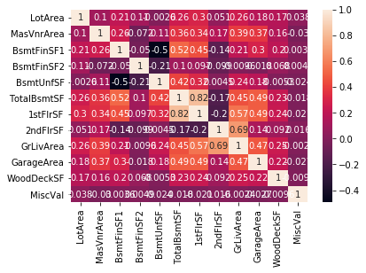

```python
sns.heatmap(tcorr,annot=True)
plt.show()
```